# aula_2_experimental

[figure not shown]

Escola Superior de Agricultura “Luiz de Queiroz”

Departamento de Genética

LGN 313 - Melhoramento Genético

**Experimentação no melhoramento vegetal**

Prof. Saulo Chaves

Piracicaba, São Paulo, Brasil

## Conteúdo de hoje

1. Motivação e contextualização
2. Princípios básicos da experimentação
3. Delineamentos experimentais
4. Prática

# Contextualização

## A mulher e o chá

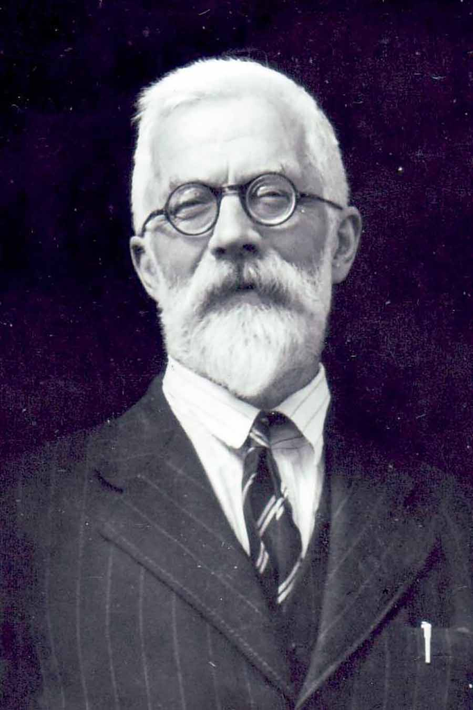

[University of Adelaide archive](https://set.adelaide.edu.au/events/list/sir-ronald-fisher-lecture)

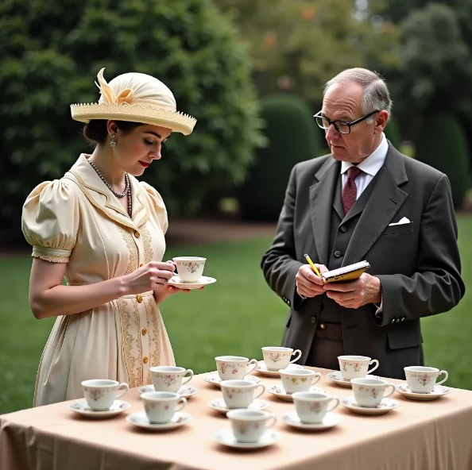

[Michael Grauslund Andersen (JYYNA)](https://jyyna.co.uk/lady-tasting-tea/)

## A mulher e o chá

☕ — ☕ — ☕ — ☕ — ☕ — ☕ — ☕ — ☕

- Hipótese nula: a mulher não consegue distinguir
- Selecionar e provar quatro xícaras aleatoriamente

$$\binom{8}{4} = \frac{8!}{4! \times 4} = \frac{8 \times 7 \times 6 \times 5}{4 \times 3 \times 2 \times 1} = 70$$

- Dado que a hipótese nula é verdadeira, probabilidade de acertar todas (ao acaso): $\frac{1}{70} = 1,4\%$

## Por que experimentar?

- Dosagem de adubo: quanto mais, melhor?
- Espaçamento: mais denso ou espaçado?
- Pós-colheita: posso aderir a uma moda?
- Melhoramento: posso selecionar com base em preferência pessoal?

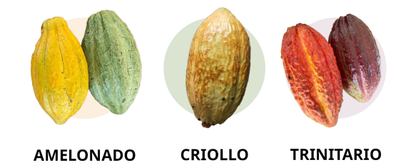

[CBI](https://www.cbi.eu/market-information/cocoa-cocoa-products/semi-finished-cocoa-products-0/market-potential)

A experimentação é a chave para o estudo da relação causa-efeito e da decisão com embasamento no método científico. Ela tem por objetivo o planejamento, execução, coleta de dados, análise de dados e interpretação dos resultados, e é parte integral da estatística. Sem uma boa experimentação, não haverá bons resultados!

## Experimentação no melhoramento

No melhoramento, nem tudo que reluz é ouro!

$$F = G + E$$

- Objetivo: selecionar genótipos com os melhores $G$
- Obstáculo: somente o $F$ é observável

## Solução: experimente!

- Experimentos permitem o isolamento do $G$

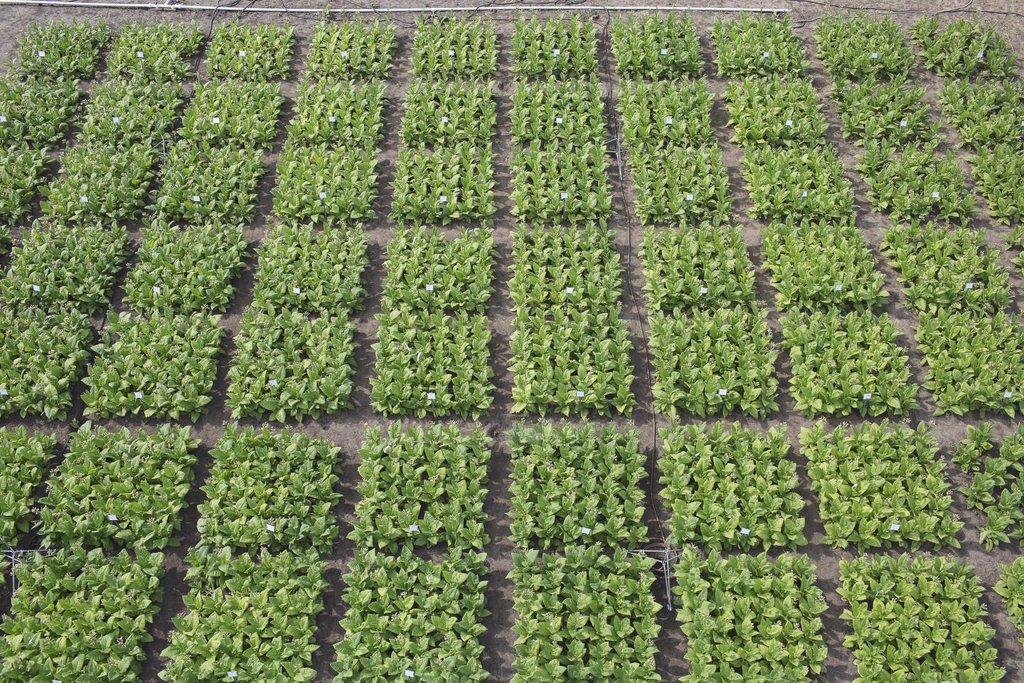

[Claudia Lutz (Phys)](https://phys.org/news/2016-01-molecular-method-food-crops.html)

## Experimento ou ensaio

- Estudo previamente planejado, que segue determinados princípios básicos, e onde comparam-se os efeitos de vários tratamentos
- Relação de causa e efeito entre dois tipos de variáveis:
  - Variável causal ou tratamento (níveis quantitativos e qualitativos)
  - Variável-resposta
- Tratamentos: material cujo efeito deseja-se medir ou comparar em um experimento

## Hipóteses

- Experimentos testam hipóteses sob condições controladas
- Afirmações de uma *possível* resposta sobre um fenômeno sob investigação.
- **Hipótese nula** ($H_0$): hipótese a ser testada
- **Hipótese alternativa** ($H_1$): hipótese que contraria $H_0$
  - Baseada em um conhecimento *a priori*
- As hipóteses são testadas após a condução de experimentos

## $H_0$: Aceita ou não rejeita?

[figure not shown]

[figure not shown]

## Visão geral de um experimento

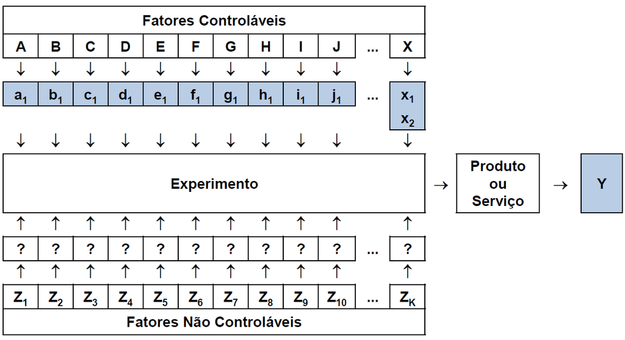

José Ivo

## E os fatores não-controláveis?

- **Erro experimental** ($\varepsilon$)
- Efeitos ambientais **aleatórios**
- Erros de medição
- $\downarrow$ variável-resposta
- $\uparrow$ variável-resposta
- Minimização do erro

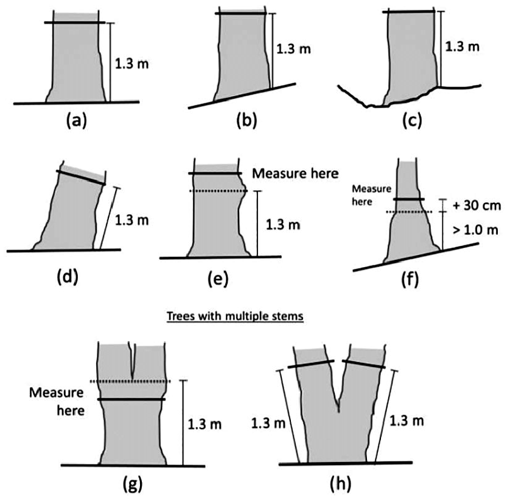

[Mola-Yudego et al. (2016)](https://www.researchgate.net/publication/311494379_Chapter_1_Wood_energy_on_a_global_scale)

## Unidade experimental

- Unidade onde se aplica o tratamento
  - Talhão, placa de petri, animal, uma árvore…
  - Também conhecido como **parcela** em experimentos de campo
- Unidade experimental $\neq$ unidade observacional
  - Exemplo: experimento com várias plantas por parcela
  - Batata: 10 plantas em cada parcela
  - 40 tratamentos $\times$ 2 repetições = 80 UE
  - 40 trat. $\times$ 2 rep. $\times$ 10 plantas/parcela = 800 UO

## Bordadura

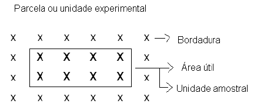

- Objetivo: isolar efeitos externos ao experimento e/ou competição entre parcelas
- Ao redor do experimento e/ou entre tratamentos
- Área total $\neq$ área útil

# Princípios básicos da experimentação

## Visão geral

- Imagine que queremos testar 4 clones de batata
- A priori, sabemos que eles são bons
- Para determinada área, queremos saber qual o melhor
- Solução: instalar um experimento
- Experimento 1:

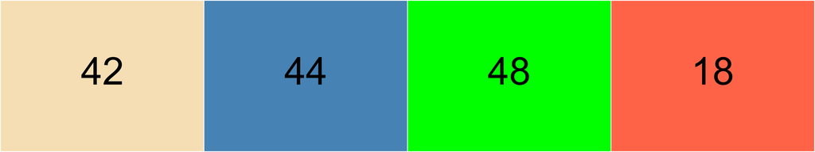

## Repetição

- Aumenta o poder do teste em detectar diferenças
- Aumenta a precisão das estimativas dos parâmetros.
- Garante a obtenção do erro experimental

$$\widehat{e}_{ij} = y_{ij} - \overline{y}_{i.}$$

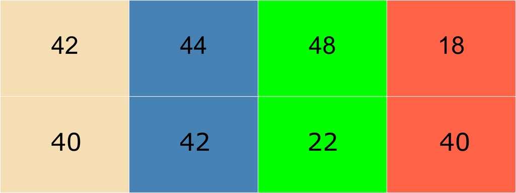

## Casualização

- Garante que não haja favorecimento de nenhum tratamento
- Valida a estimativa dos erros experimentais
- Garante a **independência dos erros experimentais**

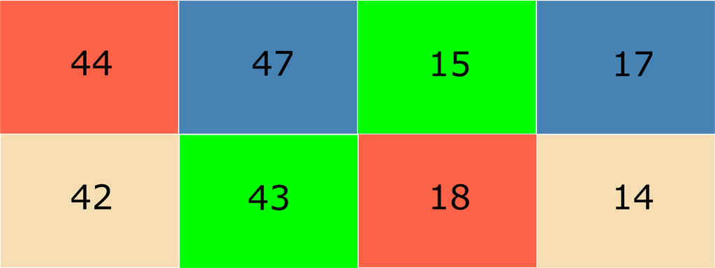

## Controle na casualização

- Se houver fatores pertubadores **controláveis** no experimento (ex.: gradientes)
- Diminui o efeito devido aos erros aleatórios
- Resultados mais confiáveis

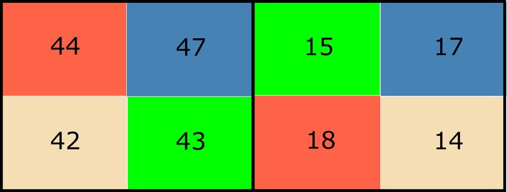

# Delineamento experimentais

## Inteiramente casualizado

- Repetição e casualização
- Adequados para ensaios com condições ambientais homogêneas
  - Exemplo: casa de vegetação, laboratórios, etc.
- O mais simples

[figure not shown]

## Blocos completos casualizados

- Repetição, casualização e controle local
- Adequados para ensaios com condições ambientais heterogêneas
  - Exemplo: campo
- O mais utilizado

[figure not shown]

## Material de apoio

- Capítulos 3, 4 e 5 do livro “Experimentação em genética e melhoramento de plantas” (Magno Ramalho, Daniel Ferreira e Antônio Oliveira) 📔
- Capítulo 2, 3, 4 e 5 do livro “Estatística experimental no RBio” (Leonardo Bhering e Paulo Teodoro) 📔
- [Experimento de Fisher: The lady tasting tea](https://www.youtube.com/watch?v=RshrFSEiqHI&ab_channel=TSATHESCIENCEACADEMY)

[figure not shown]

Grato!